# Untitled

David Sebastian Gonzalez

10/3/2021

# Objetivos

1. Continuar utilizando las funciones del conjunto de librerías [**tidyverse**](https://www.tidyverse.org/) para la manipulación y análisis de datos, y la librería [**flextable**](https://davidgohel.github.io/flextable/articles/overview.html) para la presentación de resultados.
2. Aprender a leer archivos csv.
3. Aprender a construir histogramas con ggplot: `geom_histogram()`
4. Aprender a hacer gráficas para grupos de datos: `facet_wrap()`
5. Aprender a construir tablas de frecuencias: función `tabyl()` en el paquete `janitor`.
6. Aprender a construir diagramas de barras a partir de tablas de frecuencias: `geom_col()`
7. Aprender a construir y representar gráficamente tablas de frecuencias cruzadas.

# Preliminares: carga de las librerías que utilizaremos en esta práctica.

```r
library(readxl)
library(tidyverse)
library(flextable)
library(moments)
```

# 1. Lectura de archivos csv

Los archivos `.csv`(*comma separated values*) son archivos de texto en los que los valores de las variables están separados por comas (en los archivos csv versión inglesa) o por punto y coma (en versión española). Asimismo, en los archivos en versión inglesa, el separador decimal es un punto, mientras que en la versión española el separador decimal es una coma.

Para leer este archivo utilizaremos la función `read_csv2()` (si el archivo estuviera en el estándar inglés usaríamos `read_csv()`):

```r
#tortugas <- read_csv2("DatosP1.csv")
```

la linea donde se leía el archivo de datos:

```r
tortugas <- read_excel("datosP1.xlsx")
```

La borramos y la sustituimos por la anterior.

# 2. Gráficos con ggplot: histogramas `geom_hist()`

Construye histogramas de las variables LCC, distancia y profNido.

- LCC

La sintaxis para construir un histograma con ggplot es:

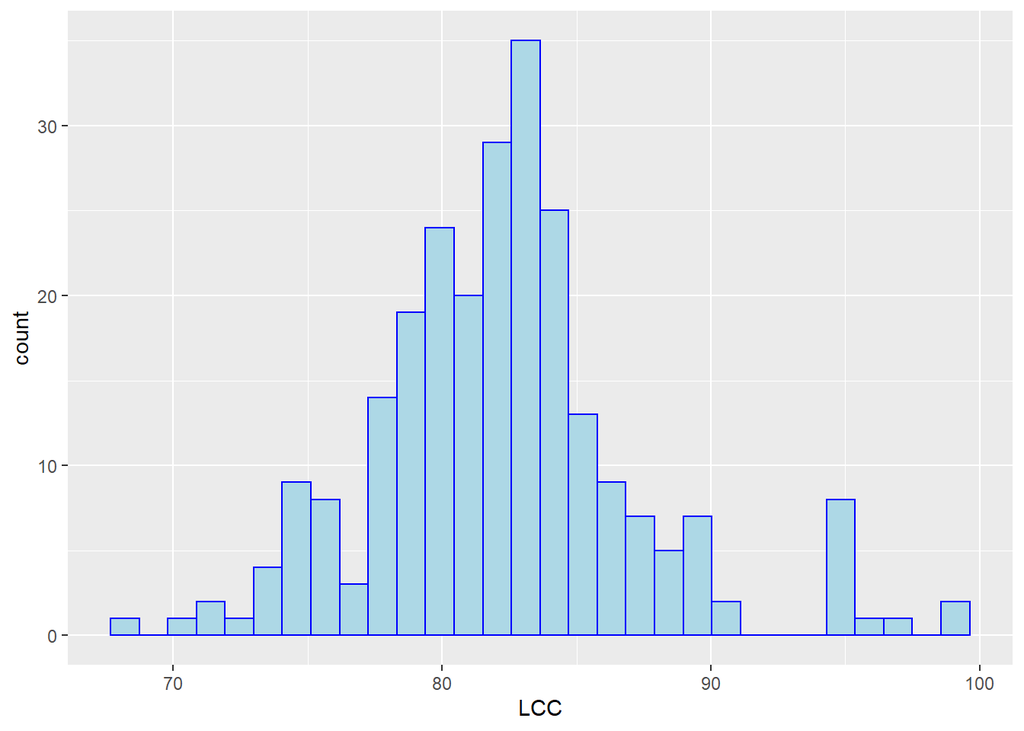

```r
tortugas %>%
  ggplot(aes(x=LCC)) + geom_histogram(color="blue", fill="lightblue")
```

Obsérvese que solo hay que especificar en `aes()` la variable cuyo histograma queremos construir. `ggplot()` calcula automáticamente las alturas de las barras. La función que construye el histograma es `geom_histogram()` y podemos especificar el color del borde de las barras (`color`) y el color del relleno (`fill`)

- Distancia desde el nido hasta la orilla

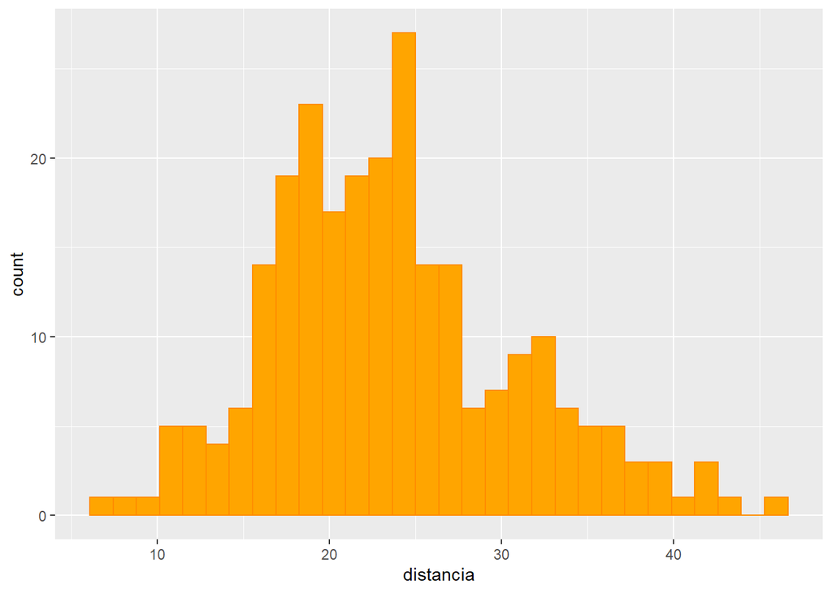

```r
tortugas %>%
  ggplot(aes(x=distancia)) + geom_histogram(color="darkorange", fill="orange")
```

- Profundidad del nido

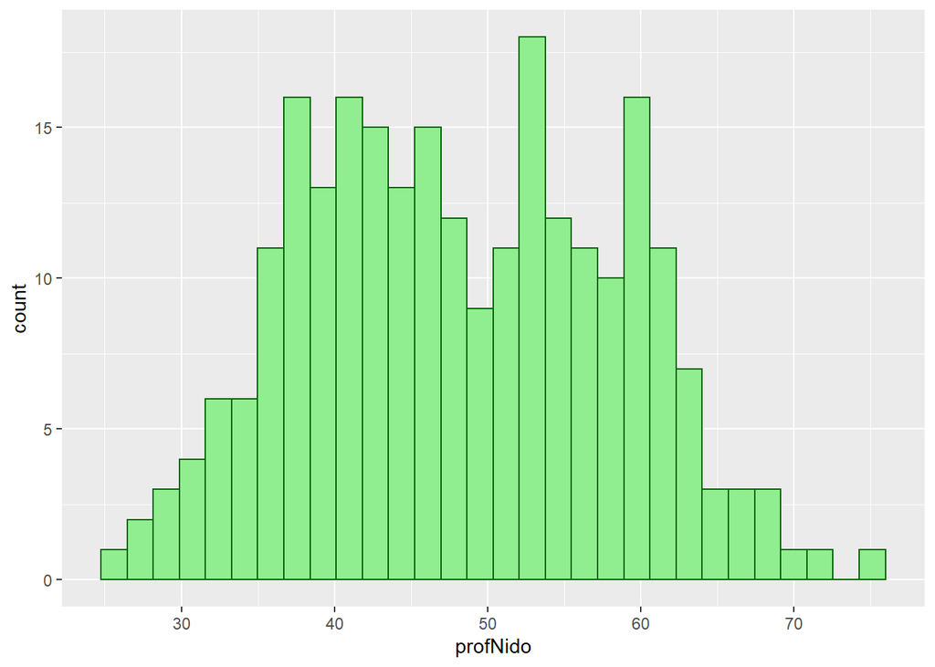

```r
tortugas %>%
  ggplot(aes(x=profNido)) + geom_histogram(color="darkgreen", fill="lightgreen")
```

# 3. Gráficos con ggplot: gráficos por grupos de datos

Representa la profundidad del nido frente a la distancia a la orilla, dando un color distinto a cada playa.

### 3.1. Todas las playas en la misma gráfica

En este caso basta con indicar en la estética del gráfico (`aes()`) que se va a asignar un color a cada playa:

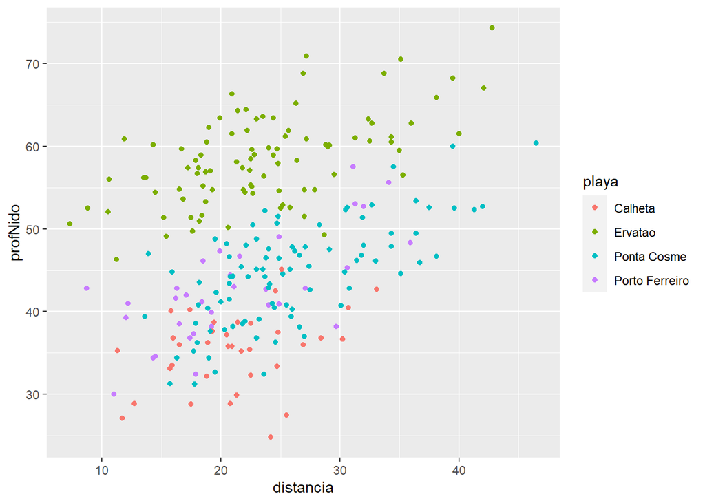

```r
tortugas %>%
  ggplot(aes(x=distancia,y=profNido,color=playa)) + geom_point()
```

### 3.2. Una gráfica distinta para cada playa.

Si queremos representar cada playa no solo con un color distinto, sino en una gráfica distinta, utilizaremos `facet_wrap()`, indicando el número de columnas (`ncol`) o de filas (`nrow`) que queremos que salgan en la gráfica:

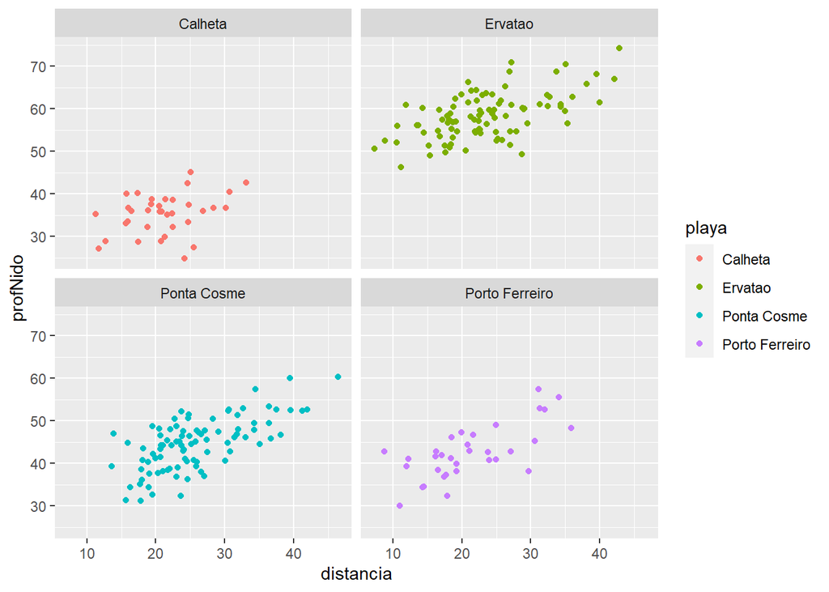

```r
tortugas %>%
  ggplot(aes(x=distancia,y=profNido,color=playa)) + geom_point() +
  facet_wrap(~playa,ncol=2)
```

# 4. Tablas de frecuencias

Construye una tabla de frecuencias con el número de nidos que hay en cada playa, así como con el porcentaje del total de nidos que representa cada playa.

En R hay varias funciones que permiten construir tablas de frecuencias. La función que mejor interactúa con el resto de funciones del *tidyverse* es la función `tabyl()` del paquete `janitor`. Para construir una tabla de frecuencias que nos indique cuántos nidos hay en cada playa procedemos del siguiente modo:

```r
library(janitor)
tortugas %>% tabyl(playa)
```

```
##           playa  n percent
##         Calheta 35   0.140
##         Ervatao 92   0.368
##     Ponta Cosme 90   0.360
##  Porto Ferreiro 33   0.132
```

Podemos mejorar, como siempre, la presentación de la tabla usando `flextable()`:

```r
tortugas %>% tabyl(playa) %>%
  flextable() %>%
  fontsize(size=14, part="all") %>%
  autofit()
```

| playa | n | percent |
| --- | --- | --- |
| Calheta | 35 | 0.140 |
| Ervatao | 92 | 0.368 |
| Ponta Cosme | 90 | 0.360 |
| Porto Ferreiro | 33 | 0.132 |

Como vemos, por defecto, la columna `percent` muestra los datos en proporciones; si queremos que los muestre en forma de porcentaje, la librería `janitor` ofrece la opción de utilizar la función `adorn_pct_formatting()`. Además utilizamos a continuación el tema `theme_box()` de la librería `flextable()` que permite formatear la tabla de otra manera:

```r
tortugas %>% tabyl(playa) %>%
  adorn_pct_formatting() %>%
  flextable() %>%
  fontsize(size=14, part="all") %>%
  autofit() %>%
  theme_box()
```

| playa | n | percent |
| --- | --- | --- |
| Calheta | 35 | 14.0% |
| Ervatao | 92 | 36.8% |
| Ponta Cosme | 90 | 36.0% |
| Porto Ferreiro | 33 | 13.2% |

Si además utilizamos la función `adorn_totals("row")`, nos añade una fila adicional a la tabla con el total de la suma de todas las filas anteriores:

```r
tortugas %>% tabyl(playa) %>%
  adorn_totals("row") %>%
  adorn_pct_formatting()%>%
  flextable() %>%
  fontsize(size=14, part="all") %>%
  autofit() %>%
  theme_box()
```

| playa | n | percent |
| --- | --- | --- |
| Calheta | 35 | 14.0% |
| Ervatao | 92 | 36.8% |
| Ponta Cosme | 90 | 36.0% |
| Porto Ferreiro | 33 | 13.2% |
| Total | 250 | 100.0% |

# 5. Tablas de frecuencias: Representación gráfica con `ggplot`

Representa el número de tortugas por playa en un diagrama de barras.

Para construir un diagrama de barras con `ggplot` debemos usar uan *geometría de columnas*, `geom_col()`. Para ello necesitamos partir de una tabla que contenga las frecuencias que queremos representar; si nos fijamos en la tabla construida en el punto anterior, la frecuencia observada para cada playa se recoge en la variable `n`. El diagrama de barras se construye entonces mediante:

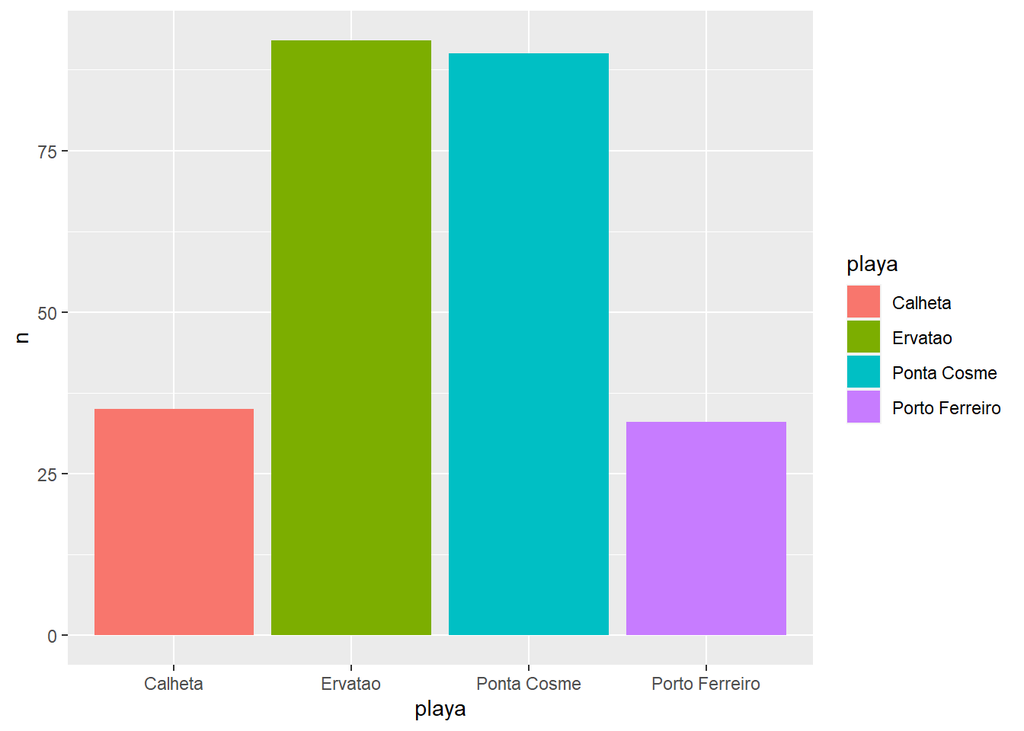

```r
tortugas %>% tabyl(playa) %>%
  ggplot(aes(x=playa,y=n,fill=playa)) +
  geom_col()
```

Como en la estética del gráfico hemos puesto `fill=playa`, cada playa se pinta de un color distinto, y se genera una leyenda a la derecha con el color que corresponde a cada playa. En realidad la leyenda es prescindible, toda vez que el nombre de cada playa aparece ya debajo de cada columna. Como la leyenda corresponde al color de relleno `fill` podemos eliminarla añadiendo `guides(fill=FALSE)`. Si además queremos poner un título al gráfico y etiquetar los ejes con otros nombres, podemos usar la función `labs()`:

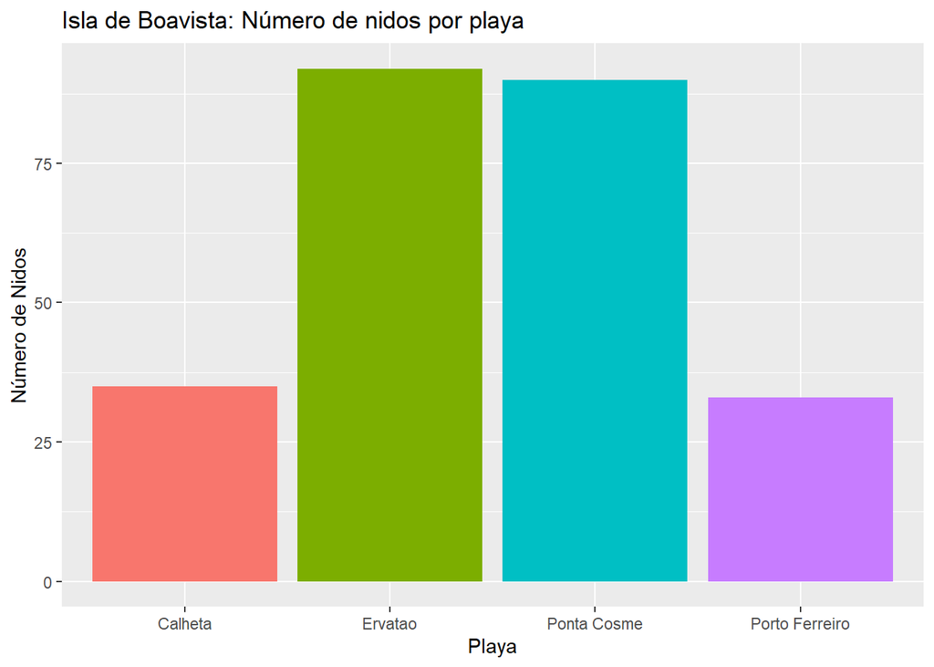

```r
tortugas %>% tabyl(playa) %>%
  ggplot(aes(x=playa,y=n,fill=playa)) +
  geom_col() +
  guides(fill=FALSE) +
  labs(x="Playa", y="Número de Nidos", title="Isla de Boavista: Número de nidos por playa")
```

Otro adorno que suele ser interesante para este tipo de gráficos, es añadir el valor numérico de la frecuencia encima de cada barra; para ello se usa la función `geom_text()`:

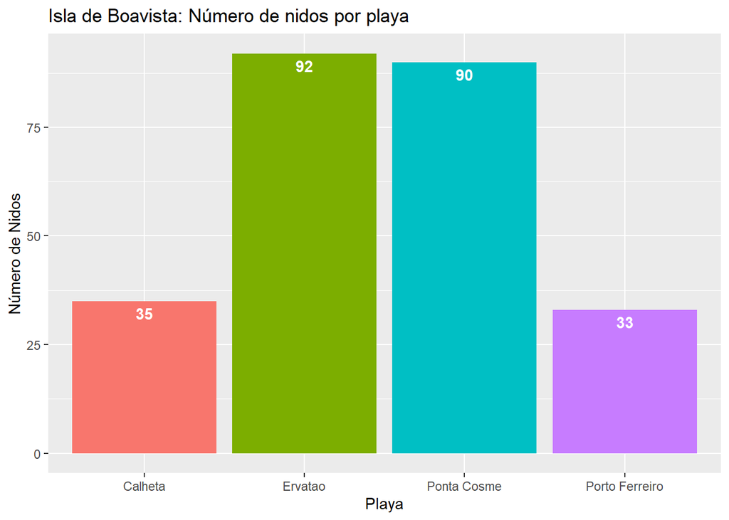

```r
tortugas %>% tabyl(playa) %>%
  ggplot(aes(x=playa,y=n,fill=playa)) +
  geom_col() +
  geom_text(aes(label=n), vjust=1.5, col="white", fontface="bold") +
  guides(fill=FALSE) +
  labs(x="Playa", y="Número de Nidos", title="Isla de Boavista: Número de nidos por playa")
```

La gráfica anterior representa las frecuencias absolutas (número de observaciones); si queremos representar las frecuencias relativas (proporción de nidos en cada playa), basta con darse cuenta de que en la tabla de frecuencias la frecuencia relativa se recoge en la variable `percent`, y lo único que habrá que hacer es indicar que la altura (`y`) de cada barra viene dada por `percent`, poniendo `y=percent` en la declaración estética `aes()` de la gráfica:

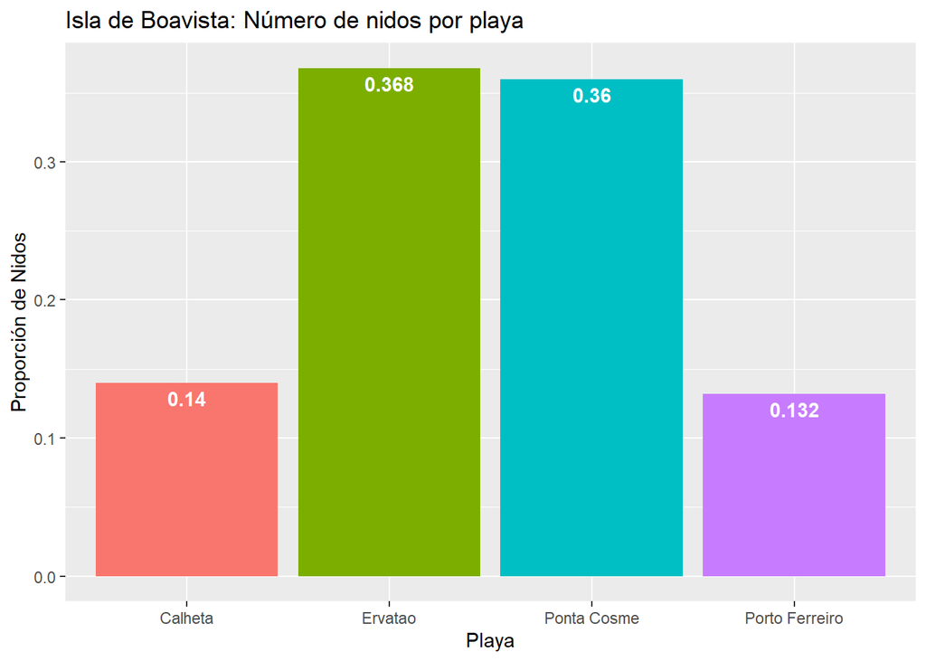

```r
tortugas %>% tabyl(playa) %>%
  ggplot(aes(x=playa, y=percent, fill=playa)) +
  geom_col() +
  geom_text(aes(label=percent), vjust=1.5, col="white", fontface="bold") +
  guides(fill=FALSE) +
  labs(x="Playa", y="Proporción de Nidos", title="Isla de Boavista: Número de nidos por playa")
```

Obviamente el valor numérico de las proporciones queda bastante feo en la gráfica anterior. Podemos arreglarlo mediante:

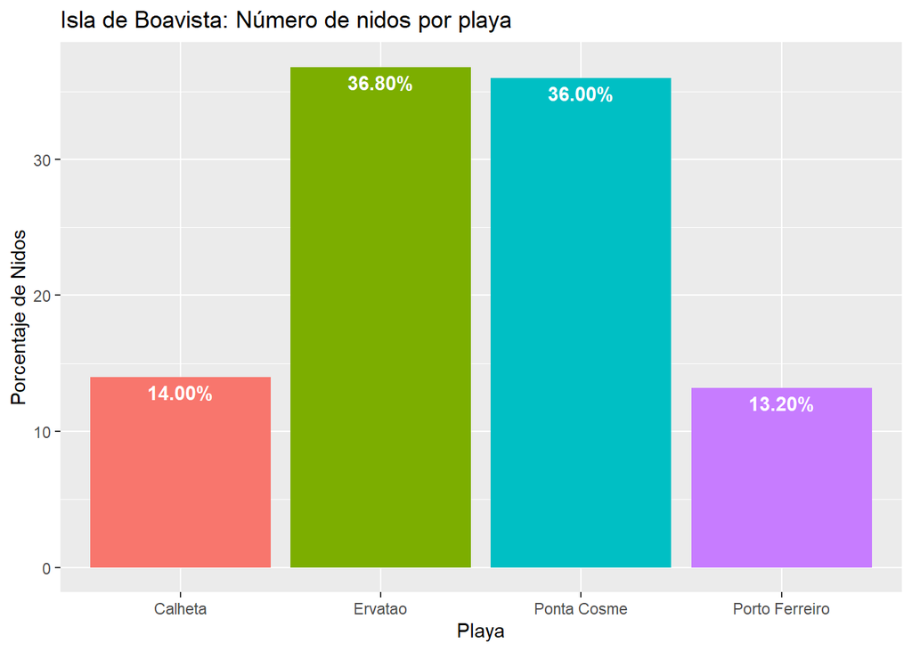

```r
tortugas %>% tabyl(playa) %>%
  ggplot(aes(x=playa,y=100*percent,fill=playa)) +
  geom_col() +
  geom_text(aes(label=sprintf("%.2f%%",100*percent)), vjust=1.5, col="white", fontface="bold") +
  guides(fill=FALSE) +
  labs(x="Playa", y="Porcentaje de Nidos", title="Isla de Boavista: Número de nidos por playa")
```

# 6. Tablas cruzadas

¿La presencia/ausencia de cangrejos en los nidos difiere entre las distintas playas? Construye una tabla cruzada de cangrejos frente a playa.

Para responder a esta pregunta debemos averiguar qué proporción de nidos están infestados de cangrejos en cada playa. Para ello podemos construir inicialmente una tabla que nos indique, para cada playa, cuántos nidos tienen cangrejos y cuántos no. Ello se consigue fácilmente con `tabyl`:

```r
tortugas %>% tabyl(cangrejos,playa)
```

```
##  cangrejos Calheta Ervatao Ponta Cosme Porto Ferreiro
##          0       7      34          22              9
##          1      18      30          47             11
##         NA      10      28          21             13
```

Si no queremos que nos muestre los valores perdidos (NA) correspondientes a nidos que no se revisaron y por tanto no se sabe si tienen o no cangrejos, usamos la opción `show_na=FALSE`:

```r
tortugas %>% tabyl(cangrejos,playa,show_na = FALSE) %>%
  flextable() %>% autofit()
```

| cangrejos | Calheta | Ervatao | Ponta Cosme | Porto Ferreiro |
| --- | --- | --- | --- | --- |
| 0 | 7 | 34 | 22 | 9 |
| 1 | 18 | 30 | 47 | 11 |

Ahora, para calcular en cada playa qué proporción de nidos tienen cangrejos y qué proporción no los tienen, habremos de calcular la proporción por columnas en la tabla anterior; ello se consigue mediante `adorn_percentages("col")`:

```r
tortugas %>% tabyl(cangrejos,playa,show_na = FALSE) %>%
  adorn_percentages("col") %>%
  flextable() %>% autofit()
```

| cangrejos | Calheta | Ervatao | Ponta Cosme | Porto Ferreiro |
| --- | --- | --- | --- | --- |
| 0 | 0.28 | 0.53125 | 0.3188406 | 0.45 |
| 1 | 0.72 | 0.46875 | 0.6811594 | 0.55 |

Podemos añadir los porcentajes globales (para todas las playas), y mostrar los resultados en forma de porcentaje:

```r
tortugas %>% tabyl(cangrejos,playa,show_na = FALSE) %>%
  adorn_totals("col") %>%
  adorn_percentages("col") %>%
  adorn_pct_formatting() %>%
  flextable() %>%
  autofit() %>%
  theme_vanilla()
```

| cangrejos | Calheta | Ervatao | Ponta Cosme | Porto Ferreiro | Total |
| --- | --- | --- | --- | --- | --- |
| 0 | 28.0% | 53.1% | 31.9% | 45.0% | 40.4% |
| 1 | 72.0% | 46.9% | 68.1% | 55.0% | 59.6% |

Si queremos, además, que junto a cada porcentaje se muestre además el número de nidos a que corresponde ese porcentaje, usamos `adorn_ns()`:

```r
tortugas %>% tabyl(cangrejos,playa,show_na = FALSE) %>%
  adorn_totals("col") %>%
  adorn_percentages("col") %>%
  adorn_pct_formatting() %>%
  adorn_ns() %>%
  flextable() %>%
  autofit() %>%
  theme_vanilla()
```

| cangrejos | Calheta | Ervatao | Ponta Cosme | Porto Ferreiro | Total |
| --- | --- | --- | --- | --- | --- |
| 0 | 28.0% (7) | 53.1% (34) | 31.9% (22) | 45.0% (9) | 40.4% (72) |
| 1 | 72.0% (18) | 46.9% (30) | 68.1% (47) | 55.0% (11) | 59.6% (106) |

# 7. Tablas cruzadas: representación gráfica con ggplot.

Representa gráficamente la tabla cruzada anterior.

```r
tortugas %>% tabyl(cangrejos,playa,show_na = FALSE)
```

```
##  cangrejos Calheta Ervatao Ponta Cosme Porto Ferreiro
##          0       7      34          22              9
##          1      18      30          47             11
```

y la tabla en formato “largo” se obtiene a partir de ésta mediante:

```r
tortugas %>% tabyl(cangrejos,playa,show_na = FALSE) %>%
  pivot_longer(cols =-1, names_to = "playa", values_to = "n")
```

```
## # A tibble: 8 x 3
##   cangrejos playa              n
##       <dbl> <chr>          <dbl>
## 1         0 Calheta            7
## 2         0 Ervatao           34
## 3         0 Ponta Cosme       22
## 4         0 Porto Ferreiro     9
## 5         1 Calheta           18
## 6         1 Ervatao           30
## 7         1 Ponta Cosme       47
## 8         1 Porto Ferreiro    11
```

En esta sintaxis le hemos indicado a R que pase a formato largo todas las columnas menos la primera (es lo que significa cols= -1), ya que la primera columna simplemente indica si hay o no cangrejos, pero no contiene ningún valor de frecuencia.

Ahora, para hacer la gráfica debemos convertir la variable `cangrejos` en factor (ya que en otro caso R consideraría que es una variable numérica) y a continuación utilizar `ggplot` y `geom_col` indicando `position="dodge"` si se quieren poner las columnas presencia/ausencia de cangrejos una junto a otra:

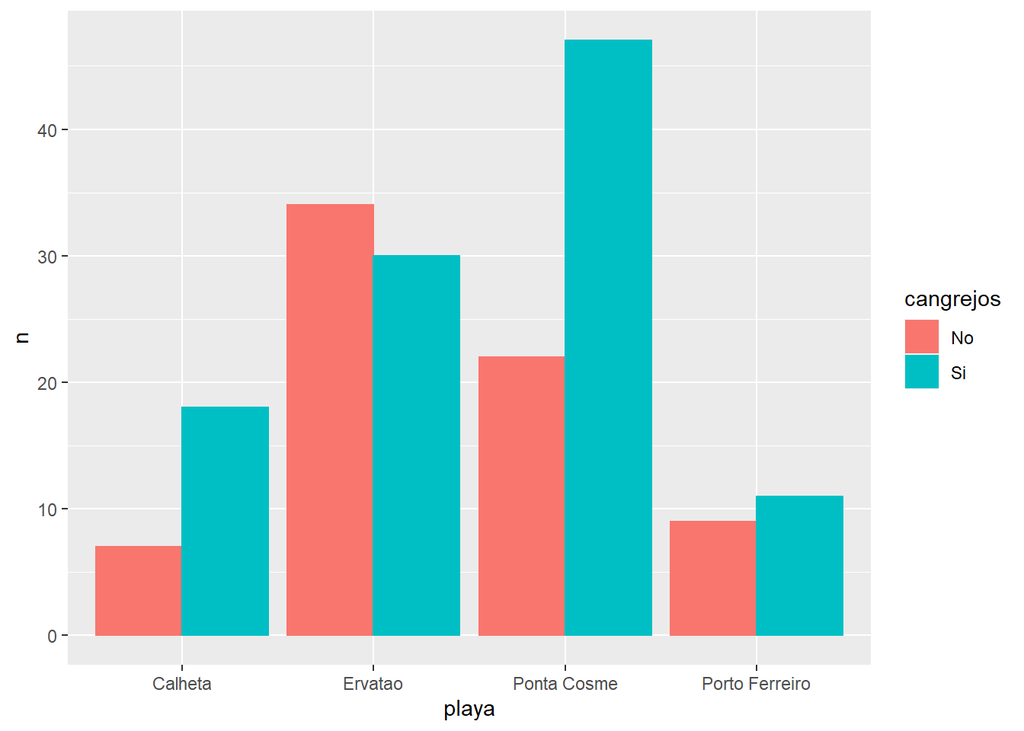

```r
tortugas %>%
  tabyl(cangrejos,playa,show_na = FALSE) %>%
  pivot_longer(cols =-1, names_to = "playa", values_to = "n") %>%
  mutate(cangrejos=factor(cangrejos,levels=c(0,1),labels=c("No","Si"))) %>%
  ggplot(aes(x=playa, y=n, fill=cangrejos, color=cangrejos)) +
  geom_col(position = "dodge")
```

También podemos poner las colummas presencia/ausencia de cangrejos una encima de otra utilizando `position="stack"`:

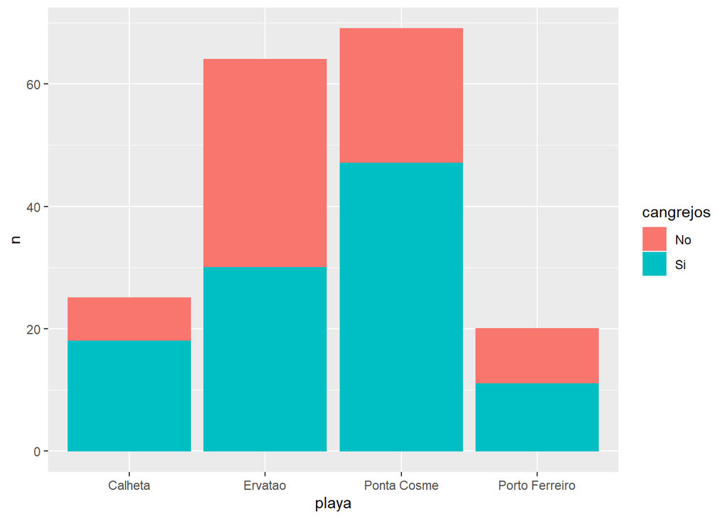

```r
tortugas %>%
  tabyl(cangrejos,playa,show_na = FALSE) %>%
  pivot_longer(cols =-1, names_to = "playa", values_to = "n") %>%
  mutate(cangrejos=factor(cangrejos,levels=c(0,1),labels=c("No","Si"))) %>%
  ggplot(aes(x=playa, y=n, fill=cangrejos, color=cangrejos)) +
  geom_col(position = "stack")
```

Si en lugar de representar frecuencias absolutas queremos representar frecuencias relativas, utilizamos la tabla que contiene los datos en proporciones y la pasamos de formato ancho a formato largo; además creamos la variable `porcentaje` multiplicando la proporción por 100:

```r
tortugas %>%
  tabyl(cangrejos,playa,show_na = FALSE) %>%
  adorn_percentages("col") %>%
  pivot_longer(cols =-1, names_to = "playa", values_to = "proporcion") %>%
  mutate(porcentaje=100*proporcion)
```

```
## # A tibble: 8 x 4
##   cangrejos playa          proporcion porcentaje
##       <dbl> <chr>               <dbl>      <dbl>
## 1         0 Calheta             0.28        28.
## 2         0 Ervatao             0.531       53.1
## 3         0 Ponta Cosme         0.319       31.9
## 4         0 Porto Ferreiro      0.45        45
## 5         1 Calheta             0.72        72
## 6         1 Ervatao             0.469       46.9
## 7         1 Ponta Cosme         0.681       68.1
## 8         1 Porto Ferreiro      0.55        55.
```

Y ahora creamos la gráfica del mismo modo que antes:

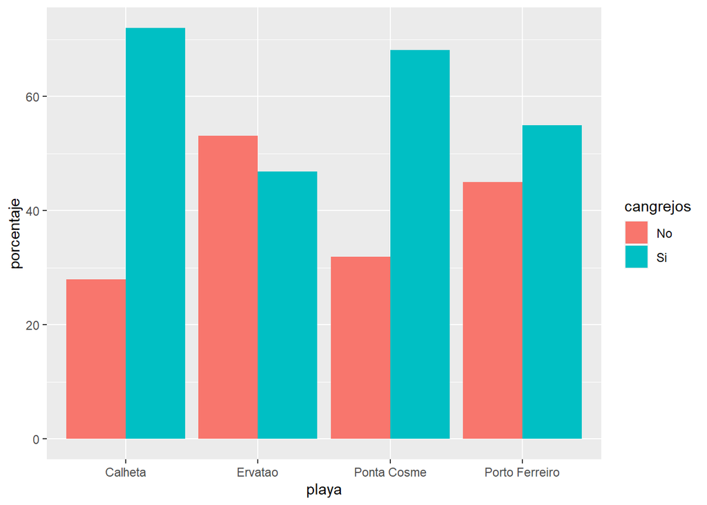

```r
tortugas %>%
  tabyl(cangrejos,playa,show_na = FALSE) %>%
  adorn_percentages("col") %>%
  pivot_longer(cols =-1, names_to = "playa", values_to = "proporcion") %>%
  mutate(porcentaje=100*proporcion) %>%
  mutate(cangrejos=factor(cangrejos,levels=c(0,1),labels=c("No","Si"))) %>%
  ggplot(aes(x=playa, y=porcentaje, fill=cangrejos)) +
  geom_col(position = "dodge")
```

Si queremos superponer el valor numérico del porcentaje a cada columna añadimos `geom_text()`:

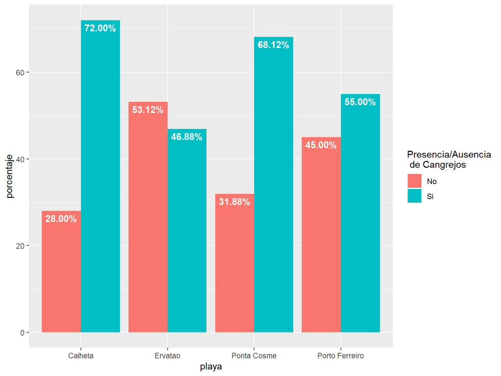

```r
tortugas %>%
  tabyl(cangrejos,playa,show_na = FALSE) %>%
  adorn_percentages("col") %>%
  pivot_longer(cols =-1, names_to = "playa", values_to = "proporcion") %>%
  mutate(porcentaje=100*proporcion) %>%
  mutate(cangrejos=factor(cangrejos,levels=c(0,1),labels=c("No","Si"))) %>%
  ggplot(aes(x=playa, y=porcentaje, fill=cangrejos)) +
  geom_col(position = "dodge") +
  geom_text(aes(label=sprintf("%.2f%%",porcentaje)),
            position=position_dodge(width=0.9),
            vjust=1.5, col="white", fontface="bold") +
  labs(fill="Presencia/Ausencia\n de Cangrejos")
```